# Dota 2 BDA SS 2017

## Gibt es Helden die erfolgreicher sind als andere?

#### Merge von Matches und Player (nur ein Team)

```python
print(mat.head())
```

```
   match_id  duration  radiant_win  hero_id  player_slot  gold  gold_spent  \
0         0      2375            1       86            0  3261       10960
1         0      2375            1       51            1  2954       17760
2         0      2375            1       83            2   110       12195
3         0      2375            1       11            3  1179       22505
4         0      2375            1       67            4  3307       23825

   kills  deaths  assists
0      9       3       18
1     13       3       18
2      0       4       15
3      8       4       19
4     20       3       17
```

```python
mat.shape
```

```
(250000, 10)
```

### Winrates der Champion

```python
hero_names[['hero_id','localized_name','winrate']].sort_values("winrate", ascending=False).head()
```

|  | hero_id | localized_name | winrate |
| --- | --- | --- | --- |
| 56 | 58 | Enchantress | 0.608492 |
| 66 | 68 | Ancient Apparition | 0.606761 |
| 101 | 103 | Elder Titan | 0.599644 |
| 41 | 43 | Death Prophet | 0.597286 |
| 84 | 86 | Rubick | 0.592802 |

### Verteilung Championwinrates

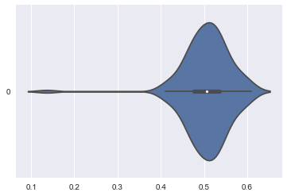

```python
sns.violinplot(data=hero_names.winrate, orient="h");
```

## Playrate von Champions

#### Regplot der Verteilung Winrate zu Anzahl gespielt

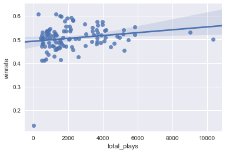

```python
sns.regplot(data=hero_names, y="winrate", x="total_plays");
```

```python
# Entfernen des Ausreisers
hero_names.drop(hero_names.winrate<0.14, inplace=True)
```

#### Bereinigter Regplot der Verteilung Winrate zu Anzahl gespielt

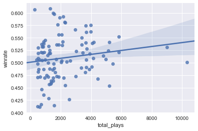

```python
sns.regplot(data=hero_names, y="winrate", x="total_plays");
```

#### Korrelation Helden zu Winrate

```python
hero_names.corr()
```

|  | total_plays | hero_id | winrate |
| --- | --- | --- | --- |
| total_plays | 1.000000 | -0.246683 | 0.157869 |
| hero_id | -0.246683 | 1.000000 | -0.013915 |
| winrate | 0.157869 | -0.013915 | 1.000000 |

## Ist die Winrate der Champions abhängig von der Spieldauer?

#### Verteilung der Spiellänge über alle Spiele

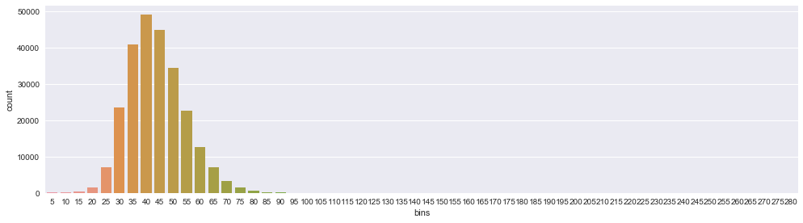

```python
# Häufigkeitsverteilung der Klassen
plt.figure(figsize=(16.69, 4.27))
sns.countplot(x='bins', data=df_mat_sort);
```

#### Verteilung in kurze/mittel/lange Spiele

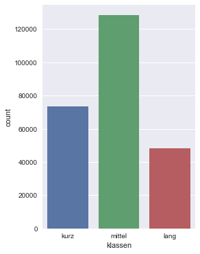

```python
plt.figure(figsize=(4, 6))
sns.countplot(x='klassen', data=df_mat_sort);
```

**Klassen**

kurz: bis 35 Minuten; mittel bis 50 Minuten; lang ab 50 Minuten

### Winrate der 10 meistgespielten Champions

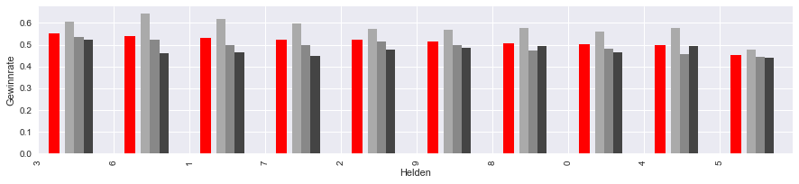

```python
fig = plt.figure(figsize=(15, 3)) # Create matplotlib figure
ax = fig.add_subplot(111) # Create matplotlib axes
ax2,ax3,ax4 = ax,ax,ax; width = 0.12
df_most_played_heros.winrate.plot(kind='bar', color='red', ax=ax, width=width*1.2, position=-1)
df_most_played_heros.winrate_kurz.plot(kind='bar', color='#aaaaaa', ax=ax2, width=width, position=-3)
df_most_played_heros.winrate_mittel.plot(kind='bar', color='#888888', ax=ax3, width=width, position=-4)
df_most_played_heros.winrate_lang.plot(kind='bar', color='#444444', ax=ax4, width=width, position=-5)
ax.set_ylabel('Gewinnrate'); ax.set_xlabel('Helden');
```

**Interpretation:** Die meistgespielten Champions sind alle stärker in kurzen Spielen. Es scheint eine allgemeine Priorität auf dieser Art zu liegen.

#### Höchste Winrate kurze Spiele

```python
df_most_played_heros[['total_plays','localized_name','winrate', 'winrate_kurz']].sort_values("winrate_kurz", ascending=False).head(3)
```

|  | total_plays | localized_name | winrate | winrate_kurz |
| --- | --- | --- | --- | --- |
| 6 | 5190.0 | Faceless Void | 0.540810 | 0.643902 |
| 1 | 9008.0 | Phantom Lancer | 0.531194 | 0.618836 |
| 3 | 5824.0 | Outworld Devourer | 0.551839 | 0.605882 |

#### Höchste Winrate mittlere Spiele

```python
df_most_played_heros[['total_plays','localized_name','winrate','winrate_mittel']].sort_values("winrate_mittel", ascending=False).head(3)
```

|  | total_plays | localized_name | winrate | winrate_mittel |
| --- | --- | --- | --- | --- |
| 3 | 5824.0 | Outworld Devourer | 0.551839 | 0.533654 |
| 6 | 5190.0 | Faceless Void | 0.540810 | 0.521333 |
| 2 | 5838.0 | Juggernaut | 0.521411 | 0.512989 |

#### Höchste Winrate lange Spiele

```python
df_most_played_heros[['total_plays','localized_name','winrate','winrate_lang']].sort_values("winrate_lang", ascending=False).head(3)
```

|  | total_plays | localized_name | winrate | winrate_lang |
| --- | --- | --- | --- | --- |
| 3 | 5824.0 | Outworld Devourer | 0.551839 | 0.522759 |
| 4 | 5445.0 | Witch Doctor | 0.498328 | 0.495763 |
| 8 | 4963.0 | Silencer | 0.507040 | 0.495719 |

## Einfluss der Chatnutzung auf die Winrate der Teams

#### Grouped Chat - Ansicht

```python
groupedchat.head(4).transpose()
```

|  | 0 | 1 | 2 | 3 |
| --- | --- | --- | --- | --- |
| match_id | 0 | 0 | 1 | 1 |
| Team | Dire | Radiant | Dire | Radiant |
| AnzahlNachrichten | 28 | 19 | 4 | 12 |
| NachrichtenLängeGesamt | 352 | 117 | 32 | 102 |
| DurchschnittlicheLänge | 12.5714 | 6.15789 | 8 | 8.5 |
| Spieldauer | 2375 | 2375 | 2582 | 2582 |
| Gewinner | Radiant | Radiant | Dire | Dire |
| NachrichtenProMinute | 0.707368 | 0.48 | 0.0929512 | 0.278854 |
| SpieldauerBereiche | 40 | 40 | 45 | 45 |
| ZeichenProMinute | 8.89263 | 2.95579 | 0.74361 | 2.37026 |

## Zusammenhang

**Zusammenhang Gewinner**

```python
ccc(pd.crosstab(groupedchat_win['Team'],groupedchat_win['NachrichtenProMinute']))
```

```
0.87748362563805871
```

**Zusammenhang Verlierer**

```python
ccc(pd.crosstab(groupedchat_lose['Team'],groupedchat_lose['NachrichtenProMinute']))
```

```
0.87894406243710055
```

## Korrelation

**Korrelation zwischen den Nachrichten pro Minute und dem Gewinner.**

```python
groupedchat_win['TeamCodes'] = groupedchat_win['Team'].cat.codes
groupedchat_win[['NachrichtenProMinute','TeamCodes']].corr()
```

|  | NachrichtenProMinute | TeamCodes |
| --- | --- | --- |
| NachrichtenProMinute | 1.000000 | 0.097489 |
| TeamCodes | 0.097489 | 1.000000 |

**Korrelation zwischen den Nachrichten pro Minute und dem Verlierer.**

```python
groupedchat_lose['TeamCodes'] = groupedchat_lose['Team'].cat.codes
groupedchat_lose[['NachrichtenProMinute','TeamCodes']].corr()
```

|  | NachrichtenProMinute | TeamCodes |
| --- | --- | --- |
| NachrichtenProMinute | 1.000000 | 0.075454 |
| TeamCodes | 0.075454 | 1.000000 |

## Visualisierung

### Winrate abängig von der Anzahl an Nachrichten pro Minute

```python
# Gemeinsamer Datensatz aus beiden getrennten Datensätzen
groupedquantile.reset_index().head(4).transpose()
```

|  | 0 | 1 | 2 | 3 |
| --- | --- | --- | --- | --- |
| BereicheNachrichtenProMinute | 0.0333704 | 0.0543478 | 0.0717703 | 0.0899213 |
| GewonneneSpiele | 965 | 1064 | 1106 | 1092 |
| VerloreneSpiele | 1664 | 1406 | 1339 | 1221 |
| GespielteSpiele | 2629 | 2470 | 2445 | 2313 |
| Winrate | 0.36706 | 0.430769 | 0.452352 | 0.472114 |
| Bereiche | 0.3 | 0.5 | 0.7 | 0.9 |

#### Diagramm

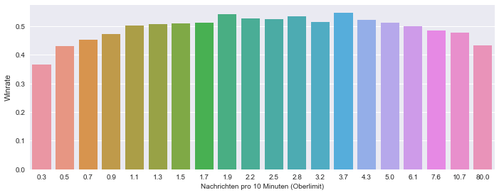

```python
# Erzeuge Barchart
plt.figure(figsize=(11.69,4.27))
sns.barplot(x=groupedquantile.Bereiche, y = groupedquantile.Winrate)
plt.xlabel('Nachrichten pro 10 Minuten (Oberlimit)', fontsize=10)
plt.ylabel('Winrate');
```

**Interpretation:** Sowohl wenig als auch zu viel Kommunikation sind schädlich für die Winrate des Teams. Bei einem gesunden Maß an Datenaustausch läuft das Spiel optimal.

### Winrate abhängig von der Anzahl der Zeichenanzahl gesendet pro Minute

#### Diagramm

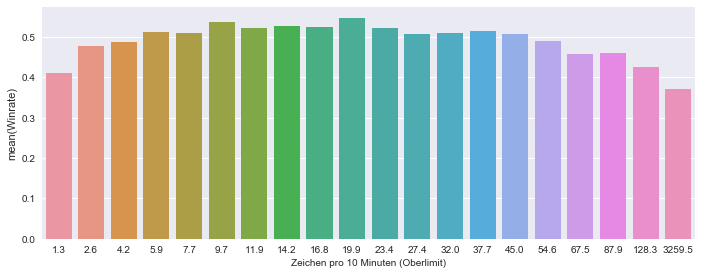

```python
# Erzeuge Barchart
plt.figure(figsize=(11.69,4.27))
sns.barplot(x=groupedquantile.Bereiche, y = groupedquantile.Winrate)
plt.xlabel('Zeichen pro 10 Minuten (Oberlimit)', fontsize=10);
```

## Gewinnchancen in Abhängigkeit von Goldanteil

#### Aufbereitete Daten

```python
mat_1.head(5).transpose()
```

|  | 0 | 1 | 2 | 3 | 4 |
| --- | --- | --- | --- | --- | --- |
| match_id | 0 | 0 | 0 | 0 | 0 |
| duration | 2375 | 2375 | 2375 | 2375 | 2375 |
| gewinner | radiant | radiant | radiant | radiant | radiant |
| hero_id | 86 | 51 | 83 | 11 | 67 |
| player_slot | 0 | 1 | 2 | 3 | 4 |
| gold | 3261 | 2954 | 110 | 1179 | 3307 |
| gold_spent | 10960 | 17760 | 12195 | 22505 | 23825 |
| kills | 9 | 13 | 0 | 8 | 20 |
| deaths | 3 | 3 | 4 | 4 | 3 |
| assists | 18 | 18 | 15 | 19 | 17 |
| team | radiant | radiant | radiant | radiant | radiant |

#### Getrennte Bereiche zur Berechnung

```python
series_total.head(5).transpose()
```

|  | 0 | 1 | 2 | 3 | 4 |
| --- | --- | --- | --- | --- | --- |
| match_id | 0 | 0 | 1 | 1 | 2 |
| total_gold | 160394 | 160394 | 190921 | 190921 | 150281 |
| gewinner | radiant | radiant | dire | dire | dire |
| team | dire | radiant | dire | radiant | dire |
| teamgold | 62338 | 98056 | 116835 | 74086 | 92797 |
| anteil | 38.8655 | 61.1345 | 61.1955 | 38.8045 | 61.749 |
| bereiche_anteil | NaN | 61 | 61 | NaN | 61 |

#### Verteilung Goldanteile bei Spielende

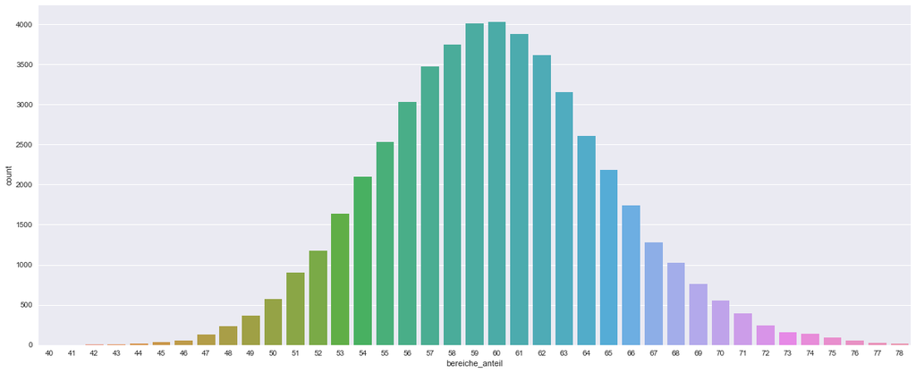

```python
plt.figure(figsize=(20.69,8.27))
sns.countplot(x='bereiche_anteil',data=series_total[series_total.gewinner == series_total.team]);
```

#### Gewinnwahrscheinlichkeit abhängig vom Goldvorsprung

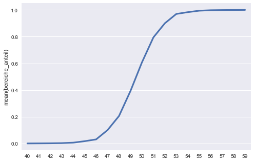

```python
fig, ax = plt.subplots(figsize=(8,5.27))
graph = x.head(20).reset_index().copy()
graph = graph.rename(columns=({'index':'bereich'}))
graph.shape
sns.pointplot( x=graph.index , y=graph.bereiche_anteil, markers='', linestyles='-')
ax.set_xticklabels(graph.bereich);
```